# Histopathologic Cancer Detection using Convolutional Neural Networks (CNN)

By Grant Novota

**Problem Statement:**  
The goal is to detect metastatic cancer in histopathology images. Specifically, we want to build a deep learning model that can identify whether or not a 96×96 image patch includes tumor tissue. This is a classification problem: each image is labeled as either tumor (1) or no tumor (0).

**Why This Matters:**  
Early and accurate detection of metastatic cancer in pathology images is vital for patient prognosis and treatment planning. Automating this process with machine learning can help pathologists handle large volumes of images more efficiently.

**Data Characteristics:**

- **Source:** [Kaggle’s Histopathologic Cancer Detection competition](https://www.kaggle.com/competitions/histopathologic-cancer-detection/overview)
- **Image Size:** 96×96 pixels
- **Color Channels:** RGB (3 channels)
- **Format:** .tif files
- **Labels:** Binary (0 = No tumor, 1 = Tumor)

A positive label (1) indicates that the **center 32×32 pixel** region contains tumor tissue. Tumor outside the center does not affect the label.

```python
import pandas as pd
import seaborn as sns
from PIL import Image
import matplotlib.pyplot as plt
import pathlib
import os

import keras
from keras.models import Sequential
from tensorflow.keras.layers import Conv2D, MaxPooling2D, Flatten, Dense, Dropout, BatchNormalization
from tensorflow.keras.preprocessing.image import ImageDataGenerator
from sklearn.model_selection import train_test_split
from keras.callbacks import EarlyStopping
```

```python
# Paths to the data directories
train_dir = 'kaggle/input/histopathologic-cancer-detection/train/'
test_dir = 'kaggle/input/histopathologic-cancer-detection/test/'

# Load the labels
labels = pd.read_csv('kaggle/input/histopathologic-cancer-detection/train_labels.csv')
```

```python
# Display the first few rows of the labels DataFrame
train_path = 'kaggle/input/histopathologic-cancer-detection/train'
test_path = 'kaggle/input/histopathologic-cancer-detection/test'
train_dir = pathlib.Path(train_path).with_suffix('')
test_dir = pathlib.Path(test_path).with_suffix('')

train_imgs = list(train_dir.glob('*.tif'))
test_imgs = list(test_dir.glob('*.tif'))

# Display the first few images
print(len(train_imgs))
print(len(test_imgs))
```

```
220025
57458
```

```python
# Get training and testing files
train_files = os.listdir(train_dir)
test_files = os.listdir(test_dir)

# Display the first few training and testing files
print('Training image files:')
print(train_files[:10])
print('Testing image files:')
print(test_files[:10])
```

```
Training image files:
['f0c2a0b8ef3024f407fa97d852d49be0215cafe0.tif', '99ef485f205645918613cd04281098daa7c17819.tif', 'e2612e173abd0e8bb54a3c3db3f264b63d80bffb.tif', '6d1bb57c0606f05dbd75f90a8d9e21a57e1267e0.tif', '9c043ab2adadfeb758c71d21432fccd3e43565c0.tif', '9cc775713dd09351172a350871a547346af08027.tif', '1996c210f0…
Testing image files:
['fd0a060ef9c30c9a83f6b4bfb568db74b099154d.tif', '1f9ee06f06d329eb7902a2e03ab3835dd0484581.tif', '19709bec800f372d0b1d085da6933dd3ef108846.tif', '7a34fc34523063f13f0617f7518a0330f6187bd3.tif', '93be720ca2b95fe2126cf2e1ed752bd759e9b0ed.tif', '761dde7de22cb39a0dd67ce472163d66e5ac1568.tif', '58055ce881…
```

## Data Preview

Here, we view a few image samples and look at the distribution of labels:

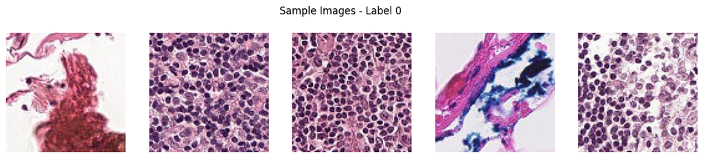

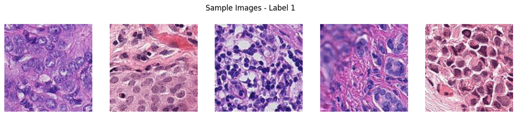

```python
# Display the first few rows of the labels DataFrame
def show_samples(label, num_samples=5):
    samples = labels[labels['label'] == label].sample(num_samples)
    plt.figure(figsize=(15, 3))
    for idx, img_name in enumerate(samples['id']):
        img_path = os.path.join(train_dir, img_name + '.tif')
        img = Image.open(img_path)
        plt.subplot(1, num_samples, idx+1)
        plt.imshow(img)
        plt.axis('off')
    plt.suptitle(f'Sample Images - Label {label}')
    plt.show()

show_samples(label=0)
show_samples(label=1)
```

```python
# Check for missing values in the labels DataFrame
print("Missing values in labels DataFrame:")
labels.isnull().sum()
```

```
Missing values in labels DataFrame:
```

```
id       0
label    0
dtype: int64
```

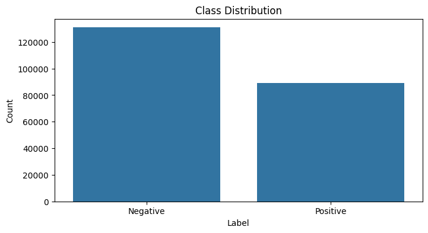

```python
# Distribution
# Plot the distribution of classes in the dataset
plt.figure(figsize=(8, 4))
sns.countplot(x='label', data=labels)
plt.title('Class Distribution')
plt.xlabel('Label')
plt.ylabel('Count')
plt.xticks([0, 1], ['Negative', 'Positive'])
plt.show()
```

# Build the Convolutional Neural Network models

## Model 1 : Baseline

Rationale: A small CNN with two convolution layers to act as a simple baseline.

```python
# Convolution and Pooling layers
config = [Conv2D(32, (3,3), activation='relu', input_shape=(96, 96, 3)),
          MaxPooling2D(2,2),

          Conv2D(64, (3,3), activation='relu'),
          MaxPooling2D(2,2),

          Flatten(),
          Dense(128, activation='relu'),
          Dense(1, activation='sigmoid')]

model = Sequential(config)
```

```python
# Compile
learning_rate = 0.001
opt = keras.optimizers.Adam(learning_rate = learning_rate)
model.compile(optimizer = opt,
              loss = 'binary_crossentropy',
              metrics = ['accuracy'])

# Summary
model.summary()
```

```
Model: "sequential"
```

```
┏━━━━━━━━━━━━━━━━━━━━━━━━━━━━━━━━━┳━━━━━━━━━━━━━━━━━━━━━━━━┳━━━━━━━━━━━━━━━┓
┃ Layer (type)                    ┃ Output Shape           ┃       Param # ┃
┡━━━━━━━━━━━━━━━━━━━━━━━━━━━━━━━━━╇━━━━━━━━━━━━━━━━━━━━━━━━╇━━━━━━━━━━━━━━━┩
│ conv2d (Conv2D)                 │ (None, 94, 94, 32)     │           896 │
├─────────────────────────────────┼────────────────────────┼───────────────┤
│ max_pooling2d (MaxPooling2D)    │ (None, 47, 47, 32)     │             0 │
├─────────────────────────────────┼────────────────────────┼───────────────┤
│ conv2d_1 (Conv2D)               │ (None, 45, 45, 64)     │        18,496 │
├─────────────────────────────────┼────────────────────────┼───────────────┤
│ max_pooling2d_1 (MaxPooling2D)  │ (None, 22, 22, 64)     │             0 │
├─────────────────────────────────┼────────────────────────┼───────────────┤
│ flatten (Flatten)               │ (None, 30976)          │             0 │
├─────────────────────────────────┼────────────────────────┼───────────────┤
│ dense (Dense)                   │ (None, 128)            │     3,965,056 │
├─────────────────────────────────┼────────────────────────┼───────────────┤
│ dense_1 (Dense)                 │ (None, 1)              │           129 │
└─────────────────────────────────┴────────────────────────┴───────────────┘
```

```
 Total params: 3,984,577 (15.20 MB)
```

```
 Trainable params: 3,984,577 (15.20 MB)
```

```
 Non-trainable params: 0 (0.00 B)
```

```python
# Data Augmentation
train_labels, val_labels = train_test_split(labels,
                                            test_size = 0.2,
                                            random_state = 0)
```

```python
train_labels.head()
```

|  | id | label |
| --- | --- | --- |
| 205571 | a42ed368dfea7e31fcde574fc9ab5ec921642cd4 | 1 |
| 18438 | 54946370aec5fe50c6c8595e880f58051445b007 | 1 |
| 47235 | a1091dc4027ac7fb5d6fdd96c6b3d3571c6adbdf | 1 |
| 42780 | 09afaac18518e435c68fc1b635690c79b52d1a0e | 0 |
| 70202 | 8ab7670b07494ca3b51b570fc243467a7a45895c | 1 |

```python
# Convert labels to strings
train_labels['label'] = train_labels['label'].astype(str)
val_labels['label'] = val_labels['label'].astype(str)

# Create a new 'filename' column by adding '.tif' extension
train_labels['filename'] = train_labels['id'] + '.tif'
val_labels['filename'] = val_labels['id'] + '.tif'
```

```python
train_labels.head()
```

|  | id | label | filename |
| --- | --- | --- | --- |
| 205571 | a42ed368dfea7e31fcde574fc9ab5ec921642cd4 | 1 | a42ed368dfea7e31fcde574fc9ab5ec921642cd4.tif |
| 18438 | 54946370aec5fe50c6c8595e880f58051445b007 | 1 | 54946370aec5fe50c6c8595e880f58051445b007.tif |
| 47235 | a1091dc4027ac7fb5d6fdd96c6b3d3571c6adbdf | 1 | a1091dc4027ac7fb5d6fdd96c6b3d3571c6adbdf.tif |
| 42780 | 09afaac18518e435c68fc1b635690c79b52d1a0e | 0 | 09afaac18518e435c68fc1b635690c79b52d1a0e.tif |
| 70202 | 8ab7670b07494ca3b51b570fc243467a7a45895c | 1 | 8ab7670b07494ca3b51b570fc243467a7a45895c.tif |

```python
# Data Generators
train_datagen = ImageDataGenerator(
    rescale=1./255,
    horizontal_flip=True,
    vertical_flip=True)

val_datagen = ImageDataGenerator(rescale=1./255)

# Train data
train_generator = train_datagen.flow_from_dataframe(
    dataframe=train_labels,
    directory=train_dir,
    x_col='filename',
    y_col='label',
    target_size=(96, 96),
    batch_size=32,
    class_mode='binary')

# Validation data
val_generator = val_datagen.flow_from_dataframe(
    dataframe=val_labels,
    directory=train_dir,
    x_col='filename',
    y_col='label',
    target_size=(96, 96),
    batch_size=32,
    class_mode='binary')
```

```
Found 176020 validated image filenames belonging to 2 classes.
Found 44005 validated image filenames belonging to 2 classes.
```

```python
# Model fitting
history = model.fit(train_generator,
                    epochs = 10,
                    validation_data = val_generator)
history
```

```
   1/5501 ━━━━━━━━━━━━━━━━━━━━ 9:46:16 6s/step - accuracy: 0.5938 - loss: 0.6702
```

```
I0000 00:00:1730569296.275926     108 device_compiler.h:188] Compiled cluster using XLA!  This line is logged at most once for the lifetime of the process.
```

```
5501/5501 ━━━━━━━━━━━━━━━━━━━━ 1554s 281ms/step - accuracy: 0.7787 - loss: 0.4797 - val_accuracy: 0.8331 - val_loss: 0.3792
5501/5501 ━━━━━━━━━━━━━━━━━━━━ 522s 95ms/step - accuracy: 0.8378 - loss: 0.3741 - val_accuracy: 0.8370 - val_loss: 0.3735
5501/5501 ━━━━━━━━━━━━━━━━━━━━ 522s 95ms/step - accuracy: 0.8526 - loss: 0.3430 - val_accuracy: 0.8607 - val_loss: 0.3276
5501/5501 ━━━━━━━━━━━━━━━━━━━━ 492s 89ms/step - accuracy: 0.8643 - loss: 0.3229 - val_accuracy: 0.8719 - val_loss: 0.3085
5501/5501 ━━━━━━━━━━━━━━━━━━━━ 472s 86ms/step - accuracy: 0.8724 - loss: 0.3051 - val_accuracy: 0.8747 - val_loss: 0.2995
5501/5501 ━━━━━━━━━━━━━━━━━━━━ 471s 85ms/step - accuracy: 0.8784 - loss: 0.2902 - val_accuracy: 0.8729 - val_loss: 0.3007
5501/5501 ━━━━━━━━━━━━━━━━━━━━ 404s 73ms/step - accuracy: 0.8848 - loss: 0.2800 - val_accuracy: 0.8851 - val_loss: 0.2797
5501/5501 ━━━━━━━━━━━━━━━━━━━━ 466s 85ms/step - accuracy: 0.8913 - loss: 0.2679 - val_accuracy: 0.8807 - val_loss: 0.2864
5501/5501 ━━━━━━━━━━━━━━━━━━━━ 558s 101ms/step - accuracy: 0.8947 - loss: 0.2586 - val_accuracy: 0.8897 - val_loss: 0.2781
5501/5501 ━━━━━━━━━━━━━━━━━━━━ 433s 79ms/step - accuracy: 0.8998 - loss: 0.2483 - val_accuracy: 0.8876 - val_loss: 0.2851
```

```
<keras.src.callbacks.history.History at 0x784568794910>
```

```python
# Plotting the learning curves
def learning_curve(history):
    acc = history.history['accuracy']
    val_acc = history.history['val_accuracy']
    loss = history.history['loss']
    val_loss = history.history['val_loss']

    plt.figure(figsize=(8, 10))
    plt.subplot(2, 1, 1)
    plt.plot(acc, label='Training Accuracy')
    plt.plot(val_acc, label='Validation Accuracy')
    plt.legend(loc='lower right')
    plt.ylabel('Accuracy')
    plt.ylim([min(plt.ylim()),1])
    plt.title('Training and Validation Accuracy')

    plt.subplot(2, 1, 2)
    plt.plot(loss, label='Training Loss')
    plt.plot(val_loss, label='Validation Loss')
    plt.legend(loc='upper right')
    plt.ylabel('Cross Entropy')
    plt.ylim([0,1.0])
    plt.title('Training and Validation Loss')
    plt.xlabel('epoch')
```

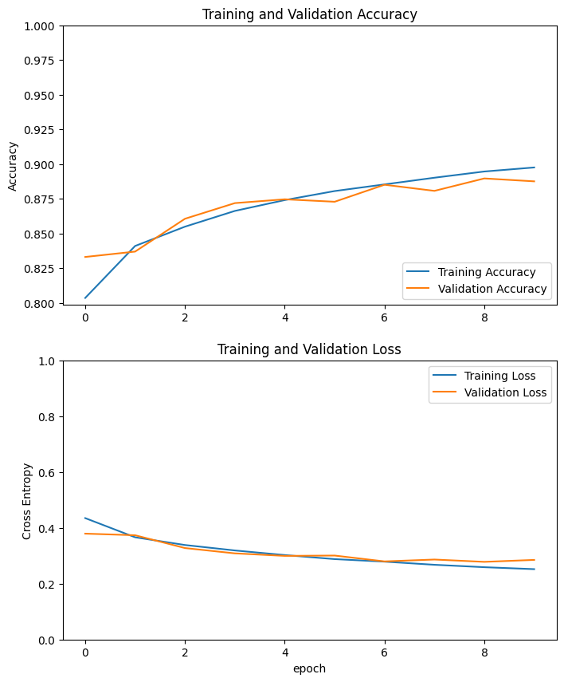

```python
learning_curve(history)
```

## Model 2 : Deeper layers with Batch Normalization and Dropout

Rationale: We add more layers to capture more complex features, plus Batch Normalization and Dropout to combat overfitting and stabilize training.

```python
# Layers
# Add Batch Normalization and Dropout layers
config_2 = [Conv2D(32, (3,3), activation='relu', input_shape=(96, 96, 3), kernel_initializer='he_normal'),
            BatchNormalization(),
            MaxPooling2D(2,2),

            Conv2D(64, (3,3), activation='relu', kernel_initializer='he_normal'),
            BatchNormalization(),
            MaxPooling2D(2,2),

            Conv2D(128, (3,3), activation='relu', kernel_initializer='he_normal'),
            BatchNormalization(),
            MaxPooling2D(2,2),

            Conv2D(256, (3,3), activation='relu', kernel_initializer='he_normal'),
            BatchNormalization(),
            MaxPooling2D(2,2),

            Flatten(),
            # Fully connected layer with Dropout
            Dense(512, activation='relu'),
            Dropout(0.5),
            Dense(1, activation='sigmoid', kernel_initializer='glorot_uniform')]

model_2 = Sequential(config_2)

# Compile
learning_rate = 0.001
opt = keras.optimizers.Adam(learning_rate = learning_rate)
model_2.compile(optimizer = opt,
              loss = 'binary_crossentropy',
              metrics = ['accuracy'])

# Summary
model_2.summary()
```

```
Model: "sequential_1"
```

```
┏━━━━━━━━━━━━━━━━━━━━━━━━━━━━━━━━━┳━━━━━━━━━━━━━━━━━━━━━━━━┳━━━━━━━━━━━━━━━┓
┃ Layer (type)                    ┃ Output Shape           ┃       Param # ┃
┡━━━━━━━━━━━━━━━━━━━━━━━━━━━━━━━━━╇━━━━━━━━━━━━━━━━━━━━━━━━╇━━━━━━━━━━━━━━━┩
│ conv2d_2 (Conv2D)               │ (None, 94, 94, 32)     │           896 │
├─────────────────────────────────┼────────────────────────┼───────────────┤
│ batch_normalization             │ (None, 94, 94, 32)     │           128 │
│ (BatchNormalization)            │                        │               │
├─────────────────────────────────┼────────────────────────┼───────────────┤
│ max_pooling2d_2 (MaxPooling2D)  │ (None, 47, 47, 32)     │             0 │
├─────────────────────────────────┼────────────────────────┼───────────────┤
│ conv2d_3 (Conv2D)               │ (None, 45, 45, 64)     │        18,496 │
├─────────────────────────────────┼────────────────────────┼───────────────┤
│ batch_normalization_1           │ (None, 45, 45, 64)     │           256 │
│ (BatchNormalization)            │                        │               │
├─────────────────────────────────┼────────────────────────┼───────────────┤
│ max_pooling2d_3 (MaxPooling2D)  │ (None, 22, 22, 64)     │             0 │
├─────────────────────────────────┼────────────────────────┼───────────────┤
│ conv2d_4 (Conv2D)               │ (None, 20, 20, 128)    │        73,856 │
├─────────────────────────────────┼────────────────────────┼───────────────┤
│ batch_normalization_2           │ (None, 20, 20, 128)    │           512 │
│ (BatchNormalization)            │                        │               │
├─────────────────────────────────┼────────────────────────┼───────────────┤
│ max_pooling2d_4 (MaxPooling2D)  │ (None, 10, 10, 128)    │             0 │
├─────────────────────────────────┼────────────────────────┼───────────────┤
│ conv2d_5 (Conv2D)               │ (None, 8, 8, 256)      │       295,168 │
├─────────────────────────────────┼────────────────────────┼───────────────┤
│ batch_normalization_3           │ (None, 8, 8, 256)      │         1,024 │
│ (BatchNormalization)            │                        │               │
├─────────────────────────────────┼────────────────────────┼───────────────┤
│ max_pooling2d_5 (MaxPooling2D)  │ (None, 4, 4, 256)      │             0 │
├─────────────────────────────────┼────────────────────────┼───────────────┤
│ flatten_1 (Flatten)             │ (None, 4096)           │             0 │
├─────────────────────────────────┼────────────────────────┼───────────────┤
│ dense_2 (Dense)                 │ (None, 512)            │     2,097,664 │
├─────────────────────────────────┼────────────────────────┼───────────────┤
│ dropout (Dropout)               │ (None, 512)            │             0 │
├─────────────────────────────────┼────────────────────────┼───────────────┤
│ dense_3 (Dense)                 │ (None, 1)              │           513 │
└─────────────────────────────────┴────────────────────────┴───────────────┘
```

```
 Total params: 2,488,513 (9.49 MB)
```

```
 Trainable params: 2,487,553 (9.49 MB)
```

```
 Non-trainable params: 960 (3.75 KB)
```

```python
# Model fitting
history_2 = model_2.fit(train_generator,
                        epochs = 6,
                        validation_data = val_generator)
history_2
```

```
5501/5501 ━━━━━━━━━━━━━━━━━━━━ 458s 82ms/step - accuracy: 0.8141 - loss: 0.5198 - val_accuracy: 0.8089 - val_loss: 0.4429
5501/5501 ━━━━━━━━━━━━━━━━━━━━ 421s 76ms/step - accuracy: 0.8873 - loss: 0.2906 - val_accuracy: 0.8986 - val_loss: 0.2561
5501/5501 ━━━━━━━━━━━━━━━━━━━━ 435s 79ms/step - accuracy: 0.9063 - loss: 0.2476 - val_accuracy: 0.8860 - val_loss: 0.2844
5501/5501 ━━━━━━━━━━━━━━━━━━━━ 416s 76ms/step - accuracy: 0.9158 - loss: 0.2252 - val_accuracy: 0.8665 - val_loss: 0.3422
5501/5501 ━━━━━━━━━━━━━━━━━━━━ 396s 72ms/step - accuracy: 0.9229 - loss: 0.2076 - val_accuracy: 0.8978 - val_loss: 0.2622
5501/5501 ━━━━━━━━━━━━━━━━━━━━ 478s 87ms/step - accuracy: 0.9271 - loss: 0.1966 - val_accuracy: 0.8225 - val_loss: 0.5008
```

```
<keras.src.callbacks.history.History at 0x7841d79ff400>
```

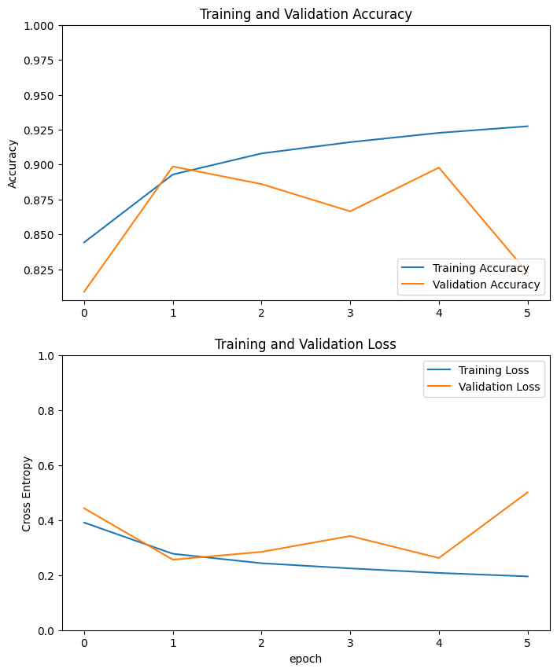

```python
learning_curve(history_2)
```

## Model 3 : Reducing the learning rate and Increase the number of epochs

Rationale: A high learning rate may overshoot local minima. Lowering it to 0.0001 and training longer (25 epochs) can yield better performance, albeit at a higher training time cost.

```python
# Layers
config_3 = [Conv2D(32, (3,3), activation='relu', input_shape=(96, 96, 3), kernel_initializer='he_normal'),
            BatchNormalization(),
            MaxPooling2D(2,2),

            Conv2D(64, (3,3), activation='relu', kernel_initializer='he_normal'),
            BatchNormalization(),
            MaxPooling2D(2,2),

            Conv2D(128, (3,3), activation='relu', kernel_initializer='he_normal'),
            BatchNormalization(),
            MaxPooling2D(2,2),

            Conv2D(256, (3,3), activation='relu', kernel_initializer='he_normal'),
            BatchNormalization(),
            MaxPooling2D(2,2),

            Flatten(),
            # Fully connected layer with Dropout
            Dense(512, activation='relu'),
            Dropout(0.5),
            Dense(1, activation='sigmoid', kernel_initializer='glorot_uniform')]

model_3 = Sequential(config_3)

# Compile
learning_rate = 0.0001 # Reduce the learning rate
opt = keras.optimizers.Adam(learning_rate = learning_rate)
model_3.compile(optimizer = opt,
                loss = 'binary_crossentropy',
                metrics = ['accuracy'])

# Summary
model_3.summary()
```

```
Model: "sequential"
```

```
┏━━━━━━━━━━━━━━━━━━━━━━━━━━━━━━━━━┳━━━━━━━━━━━━━━━━━━━━━━━━┳━━━━━━━━━━━━━━━┓
┃ Layer (type)                    ┃ Output Shape           ┃       Param # ┃
┡━━━━━━━━━━━━━━━━━━━━━━━━━━━━━━━━━╇━━━━━━━━━━━━━━━━━━━━━━━━╇━━━━━━━━━━━━━━━┩
│ conv2d (Conv2D)                 │ (None, 94, 94, 32)     │           896 │
├─────────────────────────────────┼────────────────────────┼───────────────┤
│ batch_normalization             │ (None, 94, 94, 32)     │           128 │
│ (BatchNormalization)            │                        │               │
├─────────────────────────────────┼────────────────────────┼───────────────┤
│ max_pooling2d (MaxPooling2D)    │ (None, 47, 47, 32)     │             0 │
├─────────────────────────────────┼────────────────────────┼───────────────┤
│ conv2d_1 (Conv2D)               │ (None, 45, 45, 64)     │        18,496 │
├─────────────────────────────────┼────────────────────────┼───────────────┤
│ batch_normalization_1           │ (None, 45, 45, 64)     │           256 │
│ (BatchNormalization)            │                        │               │
├─────────────────────────────────┼────────────────────────┼───────────────┤
│ max_pooling2d_1 (MaxPooling2D)  │ (None, 22, 22, 64)     │             0 │
├─────────────────────────────────┼────────────────────────┼───────────────┤
│ conv2d_2 (Conv2D)               │ (None, 20, 20, 128)    │        73,856 │
├─────────────────────────────────┼────────────────────────┼───────────────┤
│ batch_normalization_2           │ (None, 20, 20, 128)    │           512 │
│ (BatchNormalization)            │                        │               │
├─────────────────────────────────┼────────────────────────┼───────────────┤
│ max_pooling2d_2 (MaxPooling2D)  │ (None, 10, 10, 128)    │             0 │
├─────────────────────────────────┼────────────────────────┼───────────────┤
│ conv2d_3 (Conv2D)               │ (None, 8, 8, 256)      │       295,168 │
├─────────────────────────────────┼────────────────────────┼───────────────┤
│ batch_normalization_3           │ (None, 8, 8, 256)      │         1,024 │
│ (BatchNormalization)            │                        │               │
├─────────────────────────────────┼────────────────────────┼───────────────┤
│ max_pooling2d_3 (MaxPooling2D)  │ (None, 4, 4, 256)      │             0 │
├─────────────────────────────────┼────────────────────────┼───────────────┤
│ flatten (Flatten)               │ (None, 4096)           │             0 │
├─────────────────────────────────┼────────────────────────┼───────────────┤
│ dense (Dense)                   │ (None, 512)            │     2,097,664 │
├─────────────────────────────────┼────────────────────────┼───────────────┤
│ dropout (Dropout)               │ (None, 512)            │             0 │
├─────────────────────────────────┼────────────────────────┼───────────────┤
│ dense_1 (Dense)                 │ (None, 1)              │           513 │
└─────────────────────────────────┴────────────────────────┴───────────────┘
```

```
 Total params: 2,488,513 (9.49 MB)
```

```
 Trainable params: 2,487,553 (9.49 MB)
```

```
 Non-trainable params: 960 (3.75 KB)
```

```python
# Early stopping
# Define early stopping callback
# This will stop training when the validation loss has not improved for 5 epochs
# and will restore the best weights found during training
# This helps to prevent overfitting and saves the best model weights
early_stopping = EarlyStopping(monitor='val_loss', patience=5, restore_best_weights=True)

# Model fitting
# Early stopping callback
history_3 = model_3.fit(train_generator,
                        epochs = 25,
                        validation_data = val_generator,
                        callbacks = [early_stopping])

history_3
```

```
   1/5501 ━━━━━━━━━━━━━━━━━━━━ 16:11:14 11s/step - accuracy: 0.4375 - loss: 1.7451
```

```
I0000 00:00:1730599037.741051     104 device_compiler.h:188] Compiled cluster using XLA!  This line is logged at most once for the lifetime of the process.
```

```
5501/5501 ━━━━━━━━━━━━━━━━━━━━ 1272s 229ms/step - accuracy: 0.8003 - loss: 0.4616 - val_accuracy: 0.8668 - val_loss: 0.3135
5501/5501 ━━━━━━━━━━━━━━━━━━━━ 413s 75ms/step - accuracy: 0.8607 - loss: 0.3309 - val_accuracy: 0.8931 - val_loss: 0.2665
5501/5501 ━━━━━━━━━━━━━━━━━━━━ 328s 60ms/step - accuracy: 0.8836 - loss: 0.2853 - val_accuracy: 0.9041 - val_loss: 0.2433
5501/5501 ━━━━━━━━━━━━━━━━━━━━ 328s 59ms/step - accuracy: 0.8983 - loss: 0.2547 - val_accuracy: 0.9042 - val_loss: 0.2340
5501/5501 ━━━━━━━━━━━━━━━━━━━━ 334s 61ms/step - accuracy: 0.9069 - loss: 0.2359 - val_accuracy: 0.9024 - val_loss: 0.2493
5501/5501 ━━━━━━━━━━━━━━━━━━━━ 327s 59ms/step - accuracy: 0.9141 - loss: 0.2199 - val_accuracy: 0.9177 - val_loss: 0.2091
5501/5501 ━━━━━━━━━━━━━━━━━━━━ 344s 63ms/step - accuracy: 0.9211 - loss: 0.2035 - val_accuracy: 0.9302 - val_loss: 0.1835
5501/5501 ━━━━━━━━━━━━━━━━━━━━ 333s 61ms/step - accuracy: 0.9257 - loss: 0.1925 - val_accuracy: 0.9304 - val_loss: 0.1851
5501/5501 ━━━━━━━━━━━━━━━━━━━━ 332s 60ms/step - accuracy: 0.9297 - loss: 0.1823 - val_accuracy: 0.9333 - val_loss: 0.1752
5501/5501 ━━━━━━━━━━━━━━━━━━━━ 324s 59ms/step - accuracy: 0.9332 - loss: 0.1754 - val_accuracy: 0.9316 - val_loss: 0.1805
5501/5501 ━━━━━━━━━━━━━━━━━━━━ 321s 58ms/step - accuracy: 0.9371 - loss: 0.1677 - val_accuracy: 0.9324 - val_loss: 0.1860
5501/5501 ━━━━━━━━━━━━━━━━━━━━ 320s 58ms/step - accuracy: 0.9381 - loss: 0.1628 - val_accuracy: 0.9384 - val_loss: 0.1655
5501/5501 ━━━━━━━━━━━━━━━━━━━━ 378s 69ms/step - accuracy: 0.9416 - loss: 0.1555 - val_accuracy: 0.9380 - val_loss: 0.1723
5501/5501 ━━━━━━━━━━━━━━━━━━━━ 341s 62ms/step - accuracy: 0.9435 - loss: 0.1485 - val_accuracy: 0.9424 - val_loss: 0.1549
5501/5501 ━━━━━━━━━━━━━━━━━━━━ 332s 60ms/step - accuracy: 0.9452 - loss: 0.1456 - val_accuracy: 0.9362 - val_loss: 0.1727
5501/5501 ━━━━━━━━━━━━━━━━━━━━ 319s 58ms/step - accuracy: 0.9498 - loss: 0.1361 - val_accuracy: 0.9395 - val_loss: 0.1640
5501/5501 ━━━━━━━━━━━━━━━━━━━━ 331s 60ms/step - accuracy: 0.9503 - loss: 0.1338 - val_accuracy: 0.9398 - val_loss: 0.1679
5501/5501 ━━━━━━━━━━━━━━━━━━━━ 337s 61ms/step - accuracy: 0.9524 - loss: 0.1278 - val_accuracy: 0.9386 - val_loss: 0.1773
5501/5501 ━━━━━━━━━━━━━━━━━━━━ 323s 59ms/step - accuracy: 0.9540 - loss: 0.1247 - val_accuracy: 0.9347 - val_loss: 0.1773
```

```
<keras.src.callbacks.history.History at 0x7e76e00ded40>
```

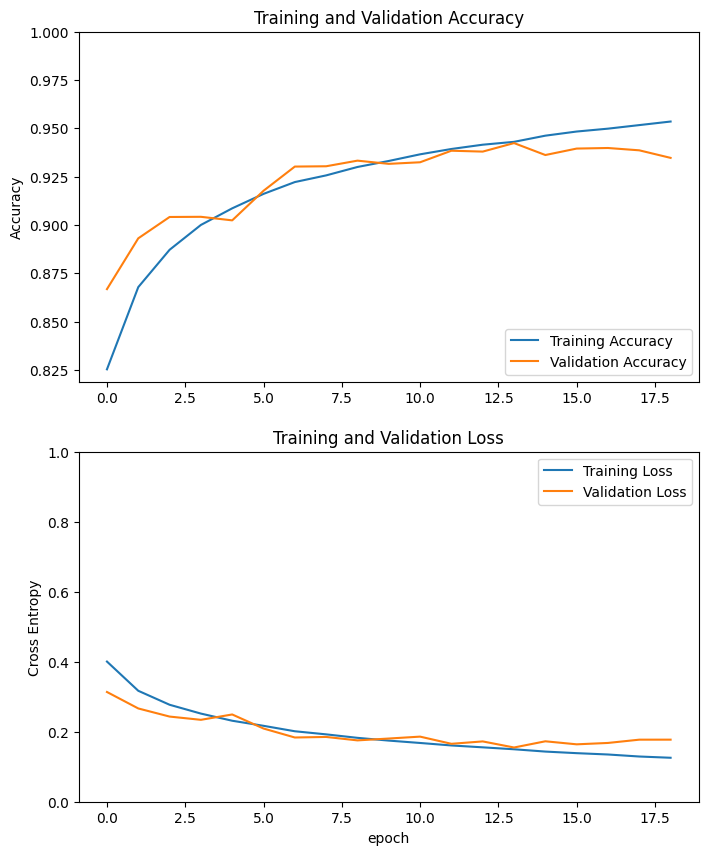

```python
learning_curve(history_3)
```

# Results

### Model 3 Results:

By reducing the learning rate and increasing epochs, we achieved steadier convergence and higher validation accuracy. Training time was significantly longer. We also noticed potential overfitting (evidenced by the gap between training and validation accuracy).

### Hyperparameter Tuning Summary

Filter sizes (32→64→128→256): to capture progressively more complex features. Batch Normalization: helps stabilize intermediate activations and speed up convergence. Dropout: helps prevent overfitting in the fully connected layers. Learning Rate: lowering it to 0.0001 gave more stable training. Epochs: More epochs were necessary after lowering the LR.

# Conclusion

## Potential Future Improvements:

- More Data Augmentation - Rotations, shifts, color jitter, etc.
- Regularization - Additional dropout or L2 regularization.
- Fine‐Tuning a Pretrained Network - Using transfer learning from a large ImageNet model might boost performance.
- Cross-Validation - Splitting the training data into multiple folds to reduce variance in validation.

```python
# Prepare test data generator
test_datagen = ImageDataGenerator(rescale=1./255)

# Create a test data generator
# The test data generator will not shuffle the data
# This is important because we need to maintain the order of the images for submission
test_generator = test_datagen.flow_from_dataframe(
    dataframe=pd.DataFrame({'id': os.listdir(test_dir)}),
    directory=test_dir,
    x_col='id',
    y_col=None,
    target_size=(96, 96),
    batch_size=32,
    class_mode=None,
    shuffle=False
)

# Predict on test data with model_3
test_generator.reset()
predictions = model_3.predict(test_generator, steps=test_generator.samples)

# Prepare the submission DataFrame
filenames = test_generator.filenames
ids = [filename.split('.')[0] for filename in filenames]
predicted_labels = (predictions > 0.5).astype(int).reshape(-1)

submission_df = pd.DataFrame({
    'id': ids,
    'label': predicted_labels
})

# Save submission.csv
submission_df.to_csv('submission_model3_final.csv', index=False)
```

```
Found 57458 validated image filenames.
57458/57458 ━━━━━━━━━━━━━━━━━━━━ 281s 5ms/step
```

## Result

| Model | val-accuracy | Private Score |
| --- | --- | --- |
| 1 | 0.8876 | 0.8424 |
| 2 | 0.8225 | 0.6899 |
| 3 | 0.9347 | 0.8601 |